# Social Network Analysis - Exercise 1

# Visualizing shortest paths

On this previous subgraph, you have to compute:

- The shortest path from the node with the highest degree to the rest of the graph.
- From all these paths, select one path with the maximum length.
- Visualize only this path using the plot function.
- Visualize this path within the giant component subgraph.

To this end, use the layout.fruchterman.reingold function to place the nodes in the visualization.

```r
# Getting the index of the node with the highest degree
maxdeg <- which.max(degree(g2))  # node number 290
maxdeg
```

```
## 290
##  57
```

```r
# Getting the list of shortest paths in the subgraph that have node 290 as origin
gsp <- get.shortest.paths(g2, maxdeg)
# Selecting from all these paths the one with the maximum length
maxl <- gsp[[1]][[which.max(sapply(gsp[[1]], length))]]
maxl
```

```
## + 7/24668 vertices, named, from 6dfde75:
## [1] 290   1056  75158 48831 57483 58271 58112
```

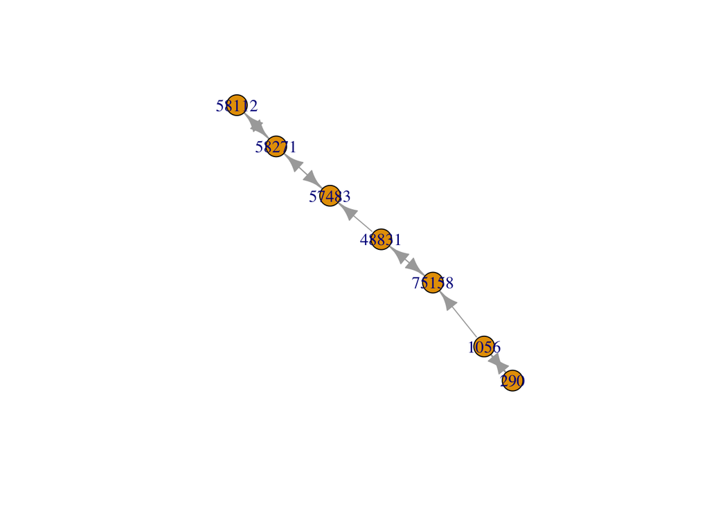

```r
# Visualise only this path using the plot function
plot_maxl <- induced_subgraph(g2, maxl)
plot(plot_maxl)
```

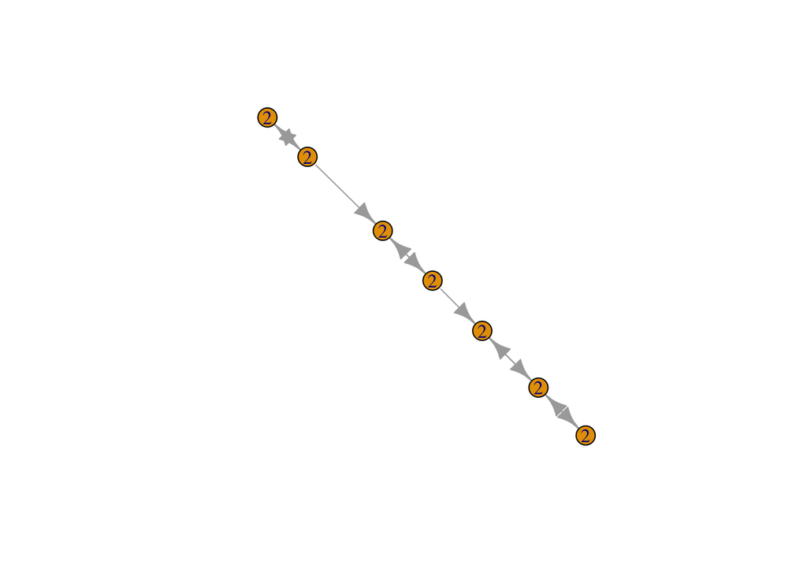

```r
# Visualise this path within the giant component subgraph
#Option 1
kc <- coreness(plot_maxl, mode="all")
plot(plot_maxl, vertex.size=kc*6, vertex.label=kc)
```

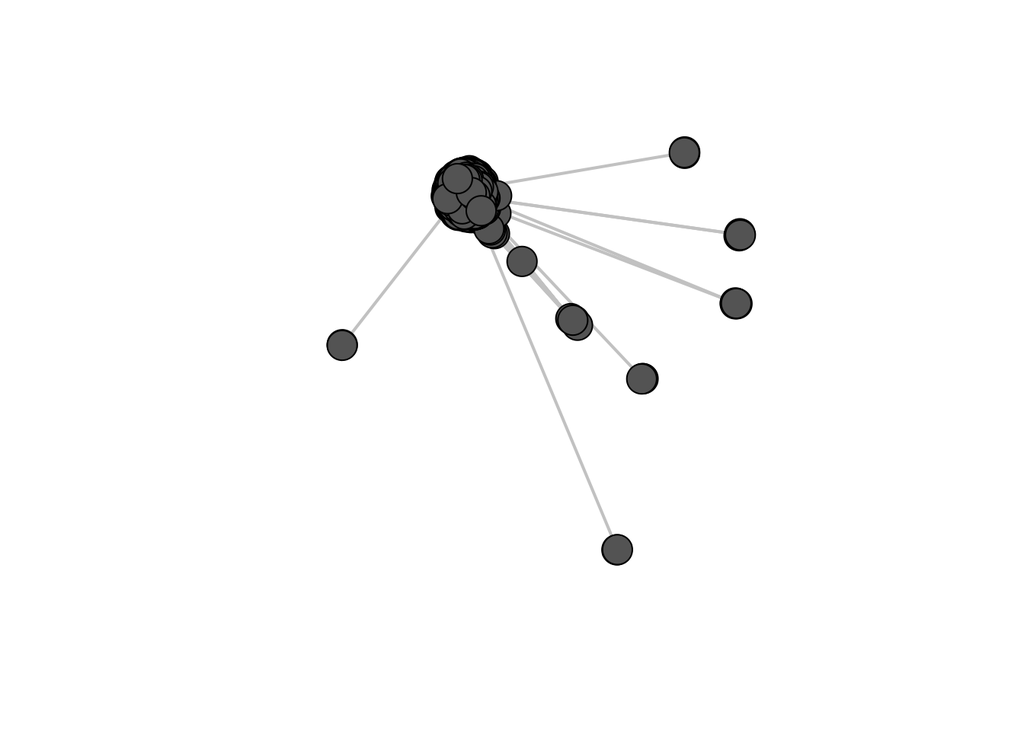

```r
#Option 2
ecol <- rep("gray80", ecount(g2))
ecol[unlist(maxl)] <- "orange"
# Generate edge width variable to plot the path:
ew <- rep(2, ecount(g2))
ew[unlist(maxl)] <- 4
# Generate node color variable to plot the path:
vcol <- rep("gray40", vcount(g2))
vcol[unlist(maxl)] <- "gold"

plot(g2, vertex.color=vcol, edge.color=ecol, edge.width=ew, edge.arrow.mode=0, vertex.label = NA )
```